# Missing Data

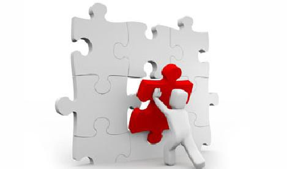

# Setup

```python
import math
import pandas as pd
import numpy as np
import matplotlib.pyplot as plt
import seaborn as sns
import missingno
import pandas_profiling

from sklearn.base import BaseEstimator
from sklearn.base import TransformerMixin
from sklearn.pipeline import FeatureUnion
from sklearn.pipeline import Pipeline
from sklearn.pipeline import make_pipeline

from sklearn.model_selection import train_test_split
from sklearn.metrics import mean_squared_error
from sklearn.linear_model import LinearRegression
from sklearn.neighbors import KNeighborsRegressor
from sklearn.neighbors import KNeighborsClassifier
from sklearn.tree import DecisionTreeRegressor

from sklearn.preprocessing import OneHotEncoder
from sklearn.preprocessing import LabelEncoder
from sklearn.preprocessing import Imputer
from sklearn.impute import SimpleImputer
from sklearn.impute import MissingIndicator
from sklearn.experimental import enable_iterative_imputer
from sklearn.impute import IterativeImputer

from sklearn_pandas import CategoricalImputer
import xgboost as xgb
```

# Load Data

https://sci2s.ugr.es/keel/dataset/data/missing/marketing.zip

- Sex integer[1,2]
- MaritalStatus integer[1,5]
- Age integer[1,7]
- Education integer[1,6]
- Occupation integer[1,9]
- YearsInSf integer[1,5]
- DualIncome integer[1,3]
- HouseholdMembers integer[1,9]
- Under18 integer[0,9]
- HouseholdStatus integer[1,3]
- TypeOfHome integer[1,5]
- EthnicClass integer[1,8]
- Language integer[1,3]
- Income {1,2,3,4,5,6,7,8,9}

```python
cols = ['Sex',
        'MaritalStatus',
        'Age',
        'Education',
        'Occupation',
        'YearsInSf',
        'DualIncome',
        'HouseholdMembers',
        'Under18',
        'HouseholdStatus',
        'TypeOfHome',
        'EthnicClass',
        'Language',
        'Income']
df = pd.read_csv('./marketing.dat', names=cols, na_values='?')
```

We'll make some adjustments to the data frame for this demo:

- Income - we'll turn the categorical value into a nominal value
- Sex : Categorical
- MaritalStatus : Categorical
- Age : Numeric (It's really a category, but we'll treat it numerically -- just for this demo)
- Education : Categorical
- Occupation : Categorical
- YearsInSf : Numeric
- DualIncome : Categorical
- HouseholdMembers : Numeric
- Under18 : Numeric
- HouseholdStatus : Categorical
- TypeOfHome : Categorical
- EthnicClass : Categorical
- Language : Categorical

```python
np.random.seed(1337)
df['Income'] = df['Income'] * 1000.0 + np.random.normal(0, 1000)
df['Age']             = df['Age'].astype(float)
df['Under18']         = df['Under18'].astype(float)
df['Sex']             = df['Sex'].astype('category')
df['MaritalStatus']   = df['MaritalStatus'].astype('category')
df['Education']       = df['Education'].astype('category')
df['Occupation']      = df['Occupation'].astype('category')
df['DualIncome']      = df['DualIncome'].astype('category')
df['HouseholdStatus'] = df['HouseholdStatus'].astype('category')
df['TypeOfHome']      = df['TypeOfHome'].astype('category')
df['EthnicClass']     = df['EthnicClass'].astype('category')
df['Language']        = df['Language'].astype('category')
df['MaritalStatus']   = df['MaritalStatus'].astype('category')
```

```python
df.dtypes
```

```
Sex                 category
MaritalStatus       category
Age                  float64
Education           category
Occupation          category
YearsInSf            float64
DualIncome          category
HouseholdMembers     float64
Under18              float64
HouseholdStatus     category
TypeOfHome          category
EthnicClass         category
Language            category
Income               float64
dtype: object
```

# Missing Data

## Seaborn Heatmap

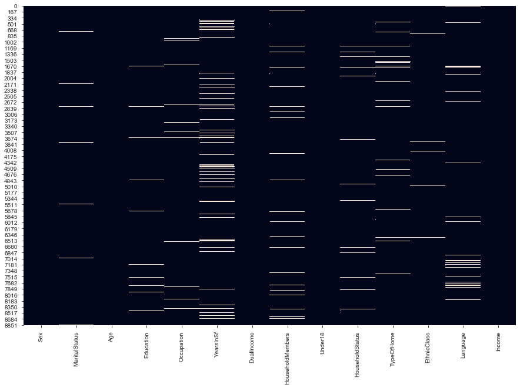

```python
plt.figure(figsize=(15,10))
sns.heatmap(df.isnull(), cbar=False)
```

## Missingno Module

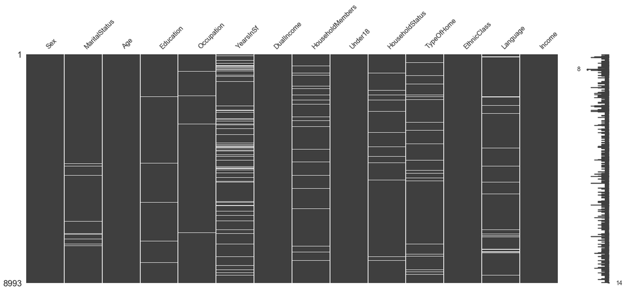

```python
missingno.matrix(df)
```

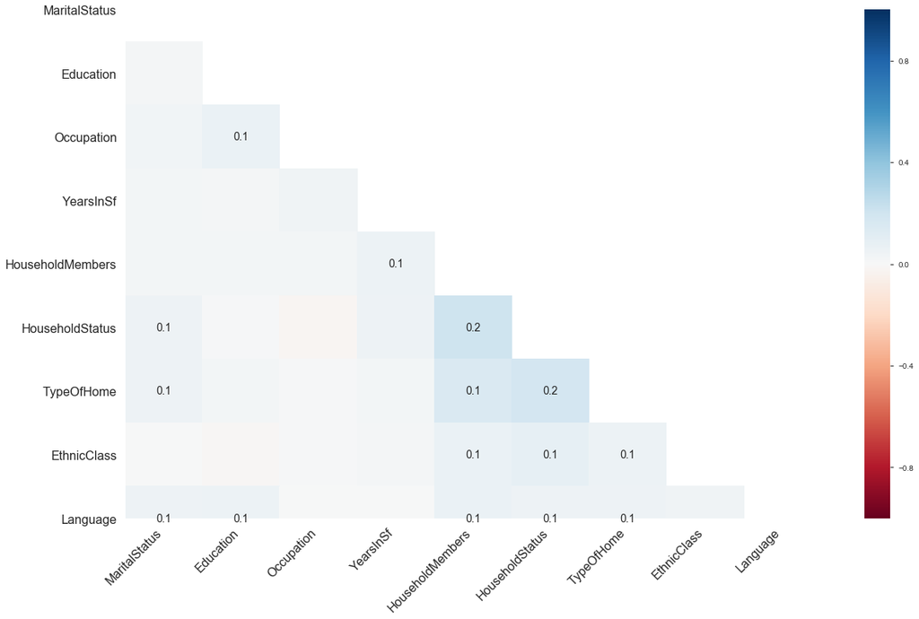

```python
missingno.heatmap(df)
```

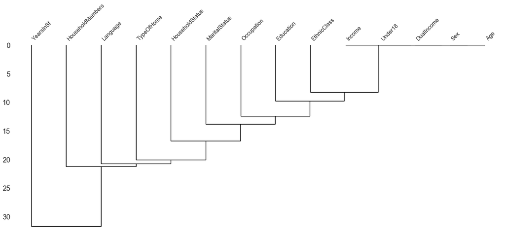

```python
missingno.dendrogram(df)
```

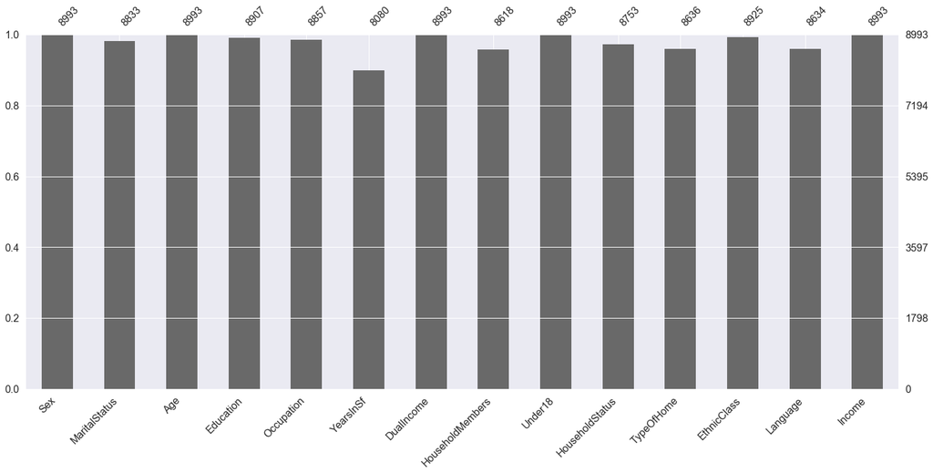

```python
missingno.bar(df)
```

# EDA

```python
df.profile_report(style={'full_width':True})
```

[interactive chart not shown]

# Evaluation

To evaluate the best treatment of missing values, we'll split our data into a train and test set. WIth the train set we'll generate a model and measure the root mean squared error (RMSE) on the test set. Models leading to smaller RMSE are considered superior to those with higher RMSE. We make a several adjustments to a typical model building exercise to simplify and focus on handling missing data. Examples include:

- Scaling / Normalization of numerical features
- Cross validation

```python
resultsDF = pd.DataFrame(columns=['RMSE'])
```

# Pipeline & Objective

For our pipeline, we're going to treat our categorical values and numeric values differently. These functions allow us to select based on columns or column dtype. We'll use that in a FeatureUnion which will handle taking different inputs, apply treatments and combine them into an array. (https://ramhiser.com/post/2018-04-16-building-scikit-learn-pipeline-with-pandas-dataframe/)

```python
class ColumnSelector(BaseEstimator, TransformerMixin):
    def __init__(self, columns):
        self.columns = columns

    def fit(self, X, y=None):
        return self

    def transform(self, X):
        assert isinstance(X, pd.DataFrame)

        try:
            return X[self.columns]
        except KeyError:
            cols_error = list(set(self.columns) - set(X.columns))
            raise KeyError("The DataFrame does not include the columns: %s" % cols_error)


class TypeSelector(BaseEstimator, TransformerMixin):
    def __init__(self, dtype):
        self.dtype = dtype

    def fit(self, X, y=None):
        return self

    def transform(self, X):
        assert isinstance(X, pd.DataFrame)
        return X.select_dtypes(include=[self.dtype])
```

# Data Removal

A trivial approach to missing data is to simply remove the missing rows / columns. Column-wise deletion is viable when the majority of entries have missing data. For example, a feature that is present in only 10-20% of rows. There are downsides to data removal strategies. First, you are reducing data that could otherwise be available for training. This could affect your accuracy. As well, removing row-wise data really hinges on the assumption that your missing values are missing completely at random (MCAR). MCAR assumes that there is no relationship between the missing value and your dataset. This assumption may be unlikely, where your data is missing at random (MAR). With MAR, you have some conditional relationship between missing values and your data. Row-wise deletion may be appropriate with MCAR and controlled for with MAR. Column-wise deletion typically affects your feature set and possibly your predictive power.

## Row Removal

```python
removedRowDF = df.dropna()
print('Removed {} of {} ({:.2f}%)'.format(df.shape[0] - removedRowDF.shape[0], df.shape[0],
                                         (df.shape[0] - removedRowDF.shape[0]) * 100.0 / df.shape[0]))
y = removedRowDF['Income']
X = removedRowDF.drop('Income', axis=1)
X_train, X_test, y_train, y_test = train_test_split(X, y, test_size=0.2, random_state=1337)

ohe = OneHotEncoder(categories='auto') #OneHotEncoder(categorical_features=X.dtypes=='category')
clf = LinearRegression()
pipe = Pipeline(steps=[('ohe', ohe), ('regression', clf)])
pipe.fit(X_train, y_train)

pred = pipe.predict(X_test)
rmse = math.sqrt(mean_squared_error(y_test, pred))
print('RMSE = {:.2f}'.format(rmse))
resultsDF.loc['Row Removal'] = [rmse]
```

```
Removed 2117 of 8993 (23.54%)
RMSE = 2007.24
```

## Column Removal

```python
removedColDF = df.dropna(axis=1)
print('Removed {} of {} columns)'.format(df.shape[1] - removedColDF.shape[1], df.shape[1],
                                          removedColDF.shape[1] * 100.0 / df.shape[1]))
y = removedColDF['Income']
X = removedColDF.drop('Income', axis=1)
X_train, X_test, y_train, y_test = train_test_split(X, y, test_size=0.2, random_state=1337)

ohe = OneHotEncoder(categories='auto') #OneHotEncoder(categorical_features=X.dtypes=='category')
clf = LinearRegression()
pipe = Pipeline(steps=[('ohe', ohe), ('regression', clf)])
pipe.fit(X_train, y_train)

pred = pipe.predict(X_test)
rmse = math.sqrt(mean_squared_error(y_test, pred))
print('RMSE = {:.2f}'.format(rmse))
resultsDF.loc['Col Removal'] = [rmse]
```

```
Removed 9 of 14 columns)
RMSE = 2239.28
```

## Results

```python
resultsDF
```

|  | RMSE |
| --- | --- |
| Row Removal | 2007.244878 |
| Col Removal | 2239.283970 |

# Max Likelihood

With this technique we look to replace a missing value with the max likelihood of the column. This is an intuitive guess that focuses on the values within a given column to make an estimated guess. Our column's maximum likelihood will draw from a measure of central tendency (mean, mode, median). This technique may be sufficient for some columns but can suffer when we have missing data that is not completely random and does not take into account correlations between the presence of missing values.

Numeric Features:

- Mean
- Median
- Mode (Most Frequent)

Categorical Features:

- Most Frequent
- Constant (Indicator Level)

## SimpleImputer - Mean

```python
y = df['Income']
X = df.drop('Income', axis=1)
X_train, X_test, y_train, y_test = train_test_split(X, y, test_size=0.2, random_state=1337)

process = make_pipeline(
    FeatureUnion(transformer_list=[
        ("numeric_features", make_pipeline(
            TypeSelector(np.number),
            SimpleImputer(strategy="mean")
        )),
        ("categorical_features", make_pipeline(
            TypeSelector("category"),
            SimpleImputer(strategy="most_frequent"),
            OneHotEncoder(categories='auto')
        ))
    ])
)

clf = LinearRegression()
pipe = Pipeline(steps=[('process', process), ('regression', clf)])
pipe.fit(X_train, y_train)

pred = pipe.predict(X_test)
rmse = math.sqrt(mean_squared_error(y_test, pred))
print('RMSE = {:.2f}'.format(rmse))
resultsDF.loc['SimpleImputer Mean'] = [rmse]
```

```
RMSE = 2061.29
```

## SimpleImputer - Mean + Indicator

```python
y = df['Income']
X = df.drop('Income', axis=1)
X_train, X_test, y_train, y_test = train_test_split(X, y, test_size=0.2, random_state=1337)

process = make_pipeline(
    FeatureUnion(transformer_list=[
        ("numeric_features", make_pipeline(
            TypeSelector(np.number),
            SimpleImputer(strategy="mean", missing_values=np.nan, add_indicator=True)
        )),
        ("categorical_features", make_pipeline(
            TypeSelector("category"),
            SimpleImputer(strategy="most_frequent"),
            OneHotEncoder(categories='auto')
        ))
    ])
)

clf = LinearRegression()
pipe = Pipeline(steps=[('process', process), ('regression', clf)])
pipe.fit(X_train, y_train)

pred = pipe.predict(X_test)
rmse = math.sqrt(mean_squared_error(y_test, pred))
print('RMSE = {:.2f}'.format(rmse))
resultsDF.loc['SimpleImputer Mean + Indicator'] = [rmse]
```

```
RMSE = 2062.45
```

## SimpleImputer - Median

```python
y = df['Income']
X = df.drop('Income', axis=1)
X_train, X_test, y_train, y_test = train_test_split(X, y, test_size=0.2, random_state=1337)

process = make_pipeline(
    FeatureUnion(transformer_list=[
        ("numeric_features", make_pipeline(
            TypeSelector(np.number),
            SimpleImputer(strategy="median", missing_values=np.nan)
        )),
        ("categorical_features", make_pipeline(
            TypeSelector("category"),
            SimpleImputer(strategy="most_frequent"),
            OneHotEncoder(categories='auto')
        ))
    ])
)

clf = LinearRegression()
pipe = Pipeline(steps=[('process', process), ('regression', clf)])
pipe.fit(X_train, y_train)

pred = pipe.predict(X_test)
rmse = math.sqrt(mean_squared_error(y_test, pred))
print('RMSE = {:.2f}'.format(rmse))
resultsDF.loc['SimpleImputer Median'] = [rmse]
```

```
RMSE = 2062.68
```

## SimpleImputer - Most Frequent

```python
### Most Frequent
y = df['Income']
X = df.drop('Income', axis=1)
X_train, X_test, y_train, y_test = train_test_split(X, y, test_size=0.2, random_state=1337)

process = make_pipeline(
    FeatureUnion(transformer_list=[
        ("numeric_features", make_pipeline(
            TypeSelector(np.number),
            SimpleImputer(strategy="most_frequent", missing_values=np.nan)
        )),
        ("categorical_features", make_pipeline(
            TypeSelector("category"),
            SimpleImputer(strategy="most_frequent"),
            OneHotEncoder(categories='auto')
        ))
    ])
)

clf = LinearRegression()
pipe = Pipeline(steps=[('process', process), ('regression', clf)])
pipe.fit(X_train, y_train)

pred = pipe.predict(X_test)
rmse = math.sqrt(mean_squared_error(y_test, pred))
print('RMSE = {:.2f}'.format(rmse))
resultsDF.loc['SimpleImputer Most Freq'] = [rmse]
```

```
RMSE = 2062.68
```

## SimpleImputer - Constant

```python
y = df['Income']
X = df.drop('Income', axis=1)

X_train, X_test, y_train, y_test = train_test_split(X, y, test_size=0.2, random_state=1337)

process = make_pipeline(
    FeatureUnion(transformer_list=[
        ("numeric_features", make_pipeline(
            TypeSelector(np.number),
            SimpleImputer(strategy="mean")
        )),
        ("categorical_features", make_pipeline(
            TypeSelector("category"),
            SimpleImputer(strategy="constant", fill_value=0),
            OneHotEncoder(categories='auto')
        ))
    ])
)

clf = LinearRegression()
pipe = Pipeline(steps=[('process', process), ('regression', clf)])
pipe.fit(X_train, y_train)

pred = pipe.predict(X_test)
rmse = math.sqrt(mean_squared_error(y_test, pred))
print('RMSE = {:.2f}'.format(rmse))
resultsDF.loc['SimpleImputer Constant'] = [rmse]
```

```
RMSE = 2059.52
```

## Results

```python
resultsDF.sort_values('RMSE', ascending=True)
```

|  | RMSE |
| --- | --- |
| Row Removal | 2007.244878 |
| SimpleImputer Constant | 2059.524342 |
| SimpleImputer Mean | 2061.290873 |
| SimpleImputer Mean + Indicator | 2062.449566 |
| SimpleImputer Median | 2062.681642 |
| SimpleImputer Most Freq | 2062.681642 |
| Col Removal | 2239.283970 |

# Iterative Imputation

We use the IterativeImputer (which came from the Fancyimpute package). Rather than MLE or dropping data, we attempt to fit a replacement of the missing value from an estimator. We can choose from a range of estimators:

- BayesRidge (Default Estimator)
- K Nearest Neighbors

## IterativeImputer - BayesRidge

```python
y = df['Income']
X = df.drop('Income', axis=1)
X_train, X_test, y_train, y_test = train_test_split(X, y, test_size=0.2, random_state=1337)

process = make_pipeline(
    FeatureUnion(transformer_list=[
        ("numeric_features", make_pipeline(
            TypeSelector(np.number),
            IterativeImputer(missing_values=np.nan)
        )),
        ("categorical_features", make_pipeline(
            TypeSelector("category"),
            SimpleImputer(strategy="constant", fill_value=0),
            OneHotEncoder(categories='auto')
        ))
    ])
)

clf = LinearRegression()
pipe = Pipeline(steps=[('process', process), ('regression', clf)])
pipe.fit(X_train, y_train)

pred = pipe.predict(X_test)
rmse = math.sqrt(mean_squared_error(y_test, pred))
print('RMSE = {:.2f}'.format(rmse))
resultsDF.loc['IterativeImputer BayesRidge'] = [rmse]
```

```
RMSE = 2060.27
```

## IterativeImputer - KNN

```python
y = df['Income']
X = df.drop('Income', axis=1)
X_train, X_test, y_train, y_test = train_test_split(X, y, test_size=0.2, random_state=1337)

est = KNeighborsRegressor(n_neighbors=5)
process = make_pipeline(
    FeatureUnion(transformer_list=[
        ("numeric_features", make_pipeline(
            TypeSelector(np.number),
            IterativeImputer(missing_values=np.nan, estimator=est)
        )),
        ("categorical_features", make_pipeline(
            TypeSelector("category"),
            SimpleImputer(strategy="constant", fill_value=0),
            OneHotEncoder(categories='auto')
        ))
    ])
)

clf = LinearRegression()
pipe = Pipeline(steps=[('process', process), ('regression', clf)])
pipe.fit(X_train, y_train)

pred = pipe.predict(X_test)
rmse = math.sqrt(mean_squared_error(y_test, pred))
print('RMSE = {:.2f}'.format(rmse))
resultsDF.loc['IterativeImputer KNN'] = [rmse]
```

```
RMSE = 2059.90
```

## IterativeImputer - Decision Tree

```python
y = df['Income']
X = df.drop('Income', axis=1)
X_train, X_test, y_train, y_test = train_test_split(X, y, test_size=0.2, random_state=1337)

est = DecisionTreeRegressor(random_state=0, max_features='sqrt')
process = make_pipeline(
    FeatureUnion(transformer_list=[
        ("numeric_features", make_pipeline(
            TypeSelector(np.number),
            IterativeImputer(missing_values=np.nan, estimator=est)
        )),
        ("categorical_features", make_pipeline(
            TypeSelector("category"),
            SimpleImputer(strategy="constant", fill_value=0),
            OneHotEncoder(categories='auto')
        ))
    ])
)

clf = LinearRegression()
pipe = Pipeline(steps=[('process', process), ('regression', clf)])
pipe.fit(X_train, y_train)

pred = pipe.predict(X_test)
rmse = math.sqrt(mean_squared_error(y_test, pred))
print('RMSE = {:.2f}'.format(rmse))
resultsDF.loc['IterativeImputer DecisionTree'] = [rmse]
```

```
RMSE = 2059.75
```

## IterativeImputer - Categorical

```python
y = df['Income']
X = df.drop('Income', axis=1)
X_train, X_test, y_train, y_test = train_test_split(X, y, test_size=0.2, random_state=1337)

estNum = KNeighborsRegressor(n_neighbors=5)
estCat = KNeighborsClassifier(n_neighbors=5)
process = make_pipeline(
    FeatureUnion(transformer_list=[
        ("numeric_features", make_pipeline(
            TypeSelector(np.number),
            IterativeImputer(missing_values=np.nan, estimator=estNum)
        )),
        ("categorical_features", make_pipeline(
            TypeSelector("category"),
            IterativeImputer(missing_values=np.nan, estimator=estCat),
            OneHotEncoder(categories='auto')
        ))
    ])
)

clf = LinearRegression()
pipe = Pipeline(steps=[('process', process), ('regression', clf)])
pipe.fit(X_train, y_train)

pred = pipe.predict(X_test)
rmse = math.sqrt(mean_squared_error(y_test, pred))
print('RMSE = {:.2f}'.format(rmse))
resultsDF.loc['IterativeImputer Categorical'] = [rmse]
```

```
RMSE = 2060.90
```

## Results

```python
resultsDF.sort_values('RMSE', ascending=True)
```

|  | RMSE |
| --- | --- |
| Row Removal | 2007.244878 |
| SimpleImputer Constant | 2059.524342 |
| IterativeImputer DecisionTree | 2059.751715 |
| IterativeImputer KNN | 2059.896082 |
| IterativeImputer BayesRidge | 2060.269798 |
| IterativeImputer Categorical | 2060.902595 |
| SimpleImputer Mean | 2061.290873 |
| SimpleImputer Mean + Indicator | 2062.449566 |
| SimpleImputer Median | 2062.681642 |
| SimpleImputer Most Freq | 2062.681642 |
| Col Removal | 2239.283970 |

# Missing Capable Models

## XGBoost - NaN

```python
y = df['Income']
X = df.drop('Income', axis=1)

X_train, X_test, y_train, y_test = train_test_split(X, y, test_size=0.2, random_state=1337)

process = make_pipeline(
    FeatureUnion(transformer_list=[
        ("numeric_features", make_pipeline(
            TypeSelector(np.number),
            SimpleImputer(strategy="constant", fill_value=-1)
        )),
        ("categorical_features", make_pipeline(
            TypeSelector("category"),
            SimpleImputer(strategy="constant", fill_value=-1),
            OneHotEncoder(categories='auto')
        ))
    ])
)

clf = xgb.XGBRegressor(objective="reg:linear", missing=-1, random_state=42)
pipe = Pipeline(steps=[('process', process), ('regression', clf)])
pipe.fit(X_train, y_train)

pred = pipe.predict(X_test)
rmse = math.sqrt(mean_squared_error(y_test, pred))
print('RMSE = {:.2f}'.format(rmse))
resultsDF.loc['XGBoost NaN'] = [rmse]
```

```
RMSE = 1959.61
```

## XGBoost - Imputed

```python
y = df['Income']
X = df.drop('Income', axis=1)

X_train, X_test, y_train, y_test = train_test_split(X, y, test_size=0.2, random_state=1337)

process = make_pipeline(
    FeatureUnion(transformer_list=[
        ("numeric_features", make_pipeline(
            TypeSelector(np.number),
            SimpleImputer(strategy="mean")
        )),
        ("categorical_features", make_pipeline(
            TypeSelector("category"),
            IterativeImputer(missing_values=np.nan, estimator=estCat),
            OneHotEncoder(categories='auto')
        ))
    ])
)

clf = xgb.XGBRegressor(objective="reg:linear", random_state=42)
pipe = Pipeline(steps=[('process', process), ('regression', clf)])
pipe.fit(X_train, y_train)

pred = pipe.predict(X_test)
rmse = math.sqrt(mean_squared_error(y_test, pred))
print('RMSE = {:.2f}'.format(rmse))
resultsDF.loc['XGBoost Imputed'] = [rmse]
```

```
RMSE = 1950.50
```

# Summary

Overall:

- Pandas-profiling is a good addition for EDA & has missing plots
- Our main strategies for dealing with missing values includes:
  - Removing missing rows / columns
  - Handling missing with Max Likelihood
  - Handling missing with Iterative Imputation
  - Using a model capable of intrinsicly handling missing (XGBoost - Tree Split)
- Feature Unions allow us to have multiple pre-processing paths

For results on this dataset:

- Imputing values for XGBoost beat missing treatment
- Row Removal beat Imputation, but can't handle Missing Data for prediction
- Best Imputation strategy was applying Mean for Numerical and a Constant level for Catgegorical (i.e. Missing)

```python
resultsDF.sort_values('RMSE')
```

|  | RMSE |
| --- | --- |
| XGBoost Imputed | 1950.497090 |
| XGBoost NaN | 1959.608475 |
| Row Removal | 2007.244878 |
| SimpleImputer Constant | 2059.524342 |
| IterativeImputer DecisionTree | 2059.751715 |
| IterativeImputer KNN | 2059.896082 |
| IterativeImputer BayesRidge | 2060.269798 |
| IterativeImputer Categorical | 2060.902595 |
| SimpleImputer Mean | 2061.290873 |
| SimpleImputer Mean + Indicator | 2062.449566 |
| SimpleImputer Median | 2062.681642 |
| SimpleImputer Most Freq | 2062.681642 |
| Col Removal | 2239.283970 |

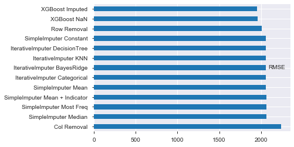

```python
resultsDF.sort_values('RMSE', ascending=False).plot.barh()
```